# Homework1-Week4

Silvy van Kuijk

September 27, 2016

### Homework - Problem 1

Every Saturday, at the same time, a primatologist goes and sits in the forest in the morning and listens for titi monkey calls, counting the number of calls they hear in a 2 hour window from 5am to 7am. Based on previous knowledge, she believes that the mean number calls she will hear in that time is exactly 15. Let $X$ represent the appropriate Poisson random variable of the number of calls heard in each monitoring session.

### What is the probability that she will hear more than 8 calls during any given session?

As this is a count, I’m assuming I’ll need to use the Poisson Distribution functions.

```r
duet.prob <- 1 - ppois(q=8, lambda=15) #Note to self: the ppois function does 8 or less, so therefore you need to do 1 - ppois!
duet.prob
```

```
## [1] 0.9625535
```

### What is the probability that she will hear no calls in a session?

```r
song.prob <- dpois(x=0, lambda=15)
song.prob
```

```
## [1] 3.059023e-07
```

### What is the probability that she will hear exactly 3 calls in a session?

```r
call.prob <- dpois(x=3, lambda=15)
call.prob
```

```
## [1] 0.0001720701
```

### Plot the relevant Poisson mass function over the values in range 0 ≤ $x$ ≤ 30.

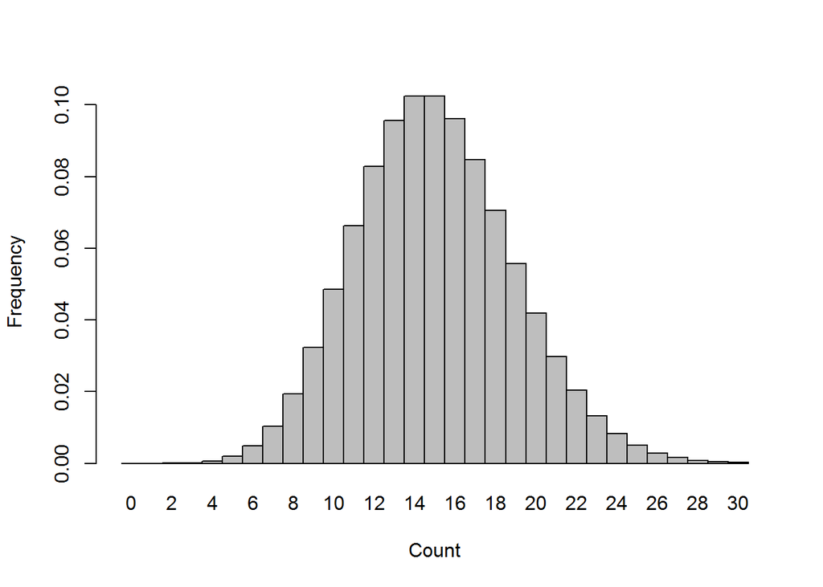

```r
#Note to self: see page 340 of 'The Book of R' for more info about this mass function!
duet.plot <- barplot(dpois(x=0:30, lambda=15), space=0, ylab="Frequency", xlab="Count", names.arg=0:30)
```

```r
duet.plot
```

```
##       [,1]
##  [1,]  0.5
##  [2,]  1.5
##  [3,]  2.5
##  [4,]  3.5
##  [5,]  4.5
##  [6,]  5.5
##  [7,]  6.5
##  [8,]  7.5
##  [9,]  8.5
## [10,]  9.5
## [11,] 10.5
## [12,] 11.5
## [13,] 12.5
## [14,] 13.5
```

[output cut: 17 more lines]

### Simulate 104 results from this distribution (i.e., 2 years of Saturday monitoring sessions).

```r
#Note to self: See page 341 of 'The Book of R'.
two.years <- rpois(n=104, lambda=15)
```

### Plot the simulated results using hist() and use xlim() to set the horizontal limits to be from 0 to 30. How does your histogram compare to the shape of the probability mass function you plotted above?

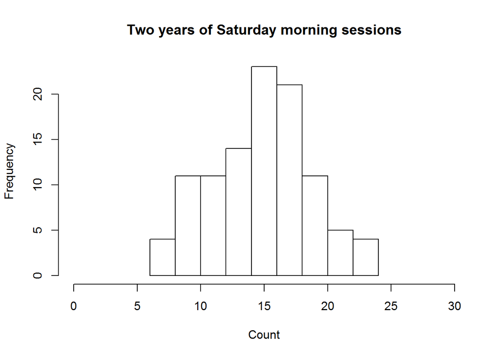

```r
hist(two.years, xlim=c(0,30), ylab="Frequency", xlab="Count", main="Two years of Saturday morning sessions")
```